# Assignment1 - Overview Data

Ramón Roales-Welsch

10 January 2018

# Executive Summary

This is the first assignment for the Data Science Specialization Captstone Project. The project consist of a Machine Learning Application for Word Suggestions (as you have them on your phone). This assignment presents the underlying datasets from online sources:

- en_US.blogs.txt
- en_US.news.txt
- en_US.twitter.txt

The datasets are provided for the Capstone Project and can be retrieved from [Coursera](https://d396qusza40orc.cloudfront.net/dsscapstone/dataset/Coursera-SwiftKey.zip). For performance reasons the data has been sampled over 100,000 observations.

# Data Summary (Sampled over 100,000)

Overview Table for the three Datasets

|  | Input Lines | Total Words | Avrg. Words per Line | Avrg. Length of Words |
| --- | --- | --- | --- | --- |
| Blogs | 1e+05 | 4171971 | 41.71971 | 4.406396 |
| News | 1e+05 | 3441739 | 34.41739 | 4.714841 |
| Twitter | 1e+05 | 1276727 | 12.76727 | 4.221064 |

# Data Plots

My first attempts were with the package ‘tidytext’ following instructions from https://www.tidytextmining.com/. Nonetheless the implementation of bigrams and trigrams seemed much easier with the ‘tokenizer’ package. Therefore I present the results from the ‘tokenizer’ package.

## Results from counting single words (With Code Example)

```
# Code example inkl. Sampling over 100,000

##Tokenizing

df_twitter <- sample(readLines('source'),100000)
df_twitter_1w <- unlist(tokenize_ngrams(df_twitter, n=1, simplify=TRUE))

##Visualization

data.frame(word=df_twitter_1w) %>%
        anti_join(stop_words) %>%
        count(word, sort = TRUE) %>%
        head(10) %>%
        mutate(word = reorder(word, n)) %>%
        ggplot(aes(word, n)) +
        geom_col() +
        xlab(NULL) +
        coord_flip() +
        ggtitle('Top 10 Words on Twitter (tokenizer)')
```

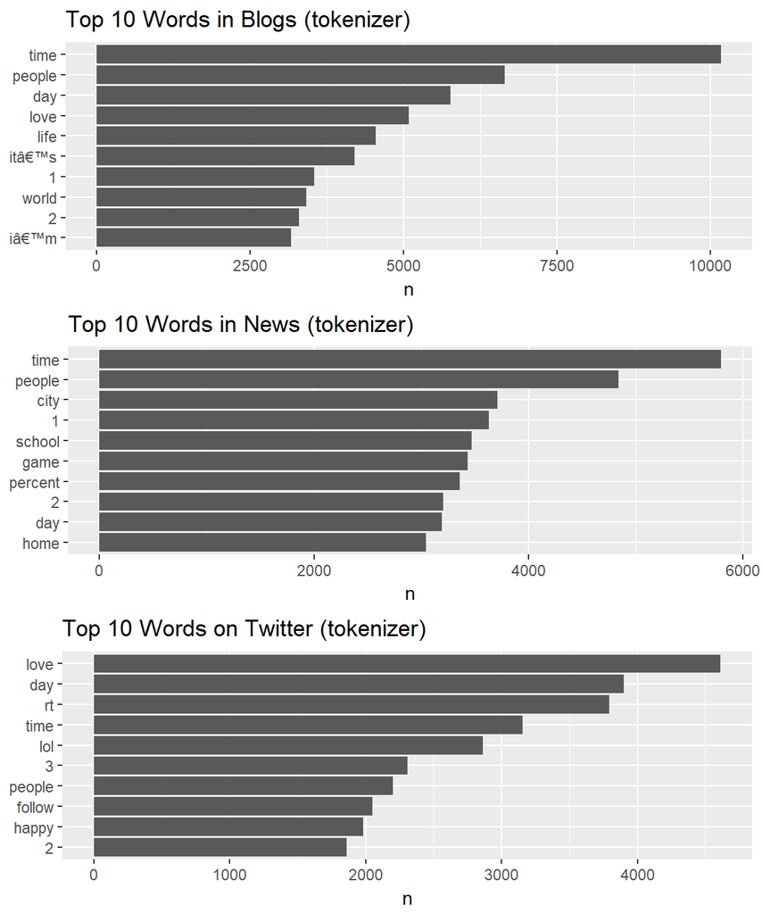

## bigrams (ngrams with n=2) using ‘tokenizer’

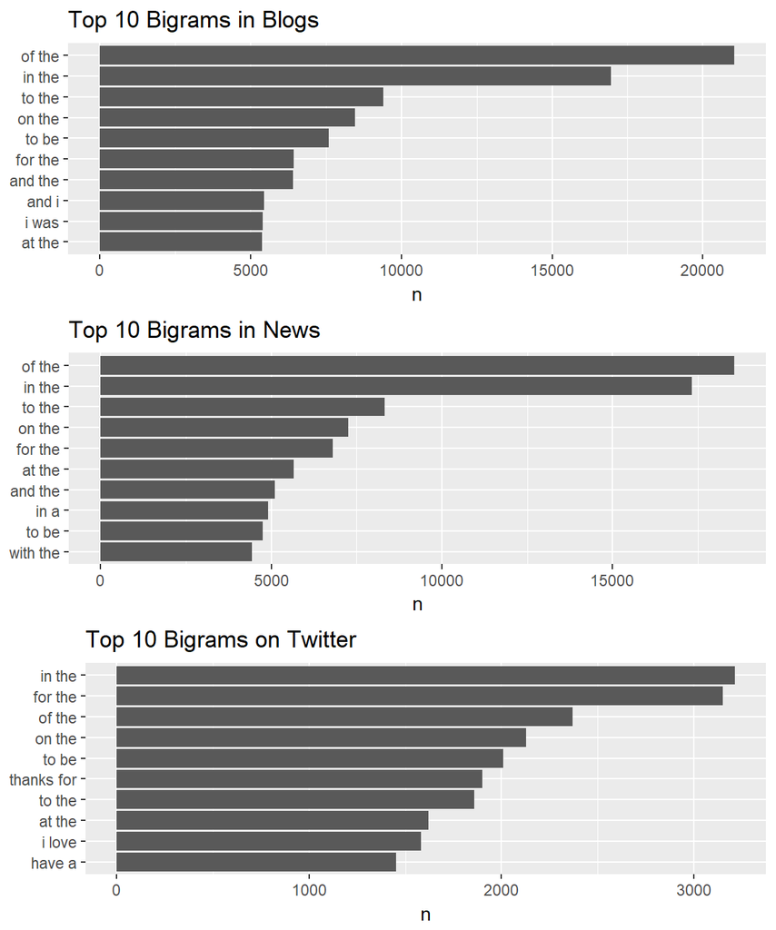

## trigrams (ngrams with n=3) using ‘tokenizer’

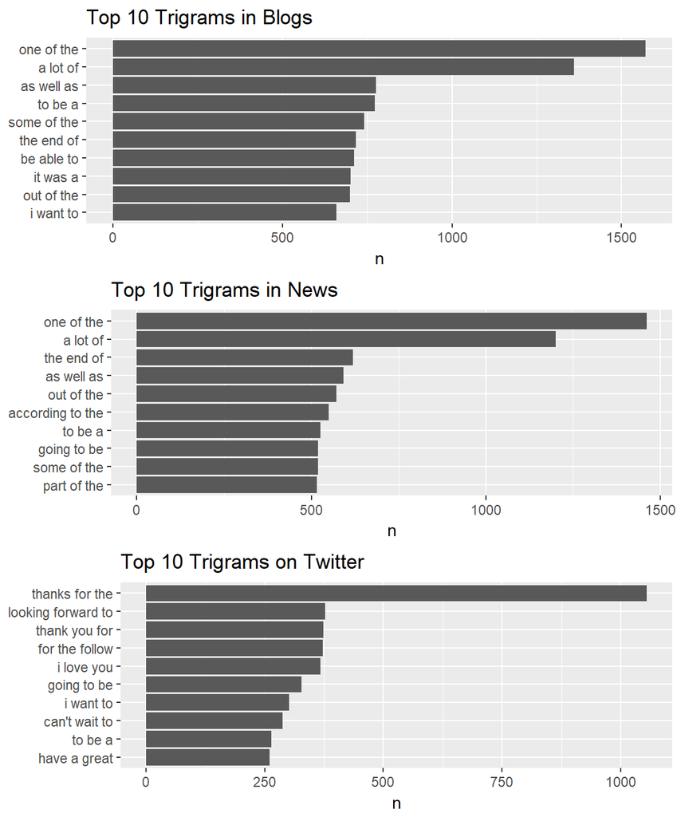

## Relationship of words between datasets (With Code)

```
# Code Chunk

##Frequency Table

frequency <- bind_rows(mutate(data.frame(word = df_blogs_1w), author = "Blogs"),
                       mutate(data.frame(word = df_news_1w), author = "News"),
                       mutate(data.frame(word = df_twitter_1w), author = "Twitter")) %>%
        mutate(word = str_extract(word,"[a-z']+")) %>%
        count(author, word) %>%
        group_by(author) %>%
        mutate(proportion = n / sum(n)) %>%
        select(-n) %>%
        spread(author, proportion) %>%
        gather(author, proportion, `Blogs`:`News`)

##Visualization

ggplot(frequency, aes(x = proportion, y = `Twitter`, color = abs(`Twitter` - proportion))) +
        geom_abline(color = "gray40", lty = 2) +
        geom_jitter(alpha = 0.1, size = 2.5, width = 0.3, height = 0.3) +
        geom_text(aes(label = word), check_overlap = TRUE, vjust = 1.5) +
        scale_x_log10(labels = percent_format()) +
        scale_y_log10(labels = percent_format()) +
        scale_color_gradient(limits = c(0, 0.001), low = "darkslategray4", high = "gray75") +
        facet_wrap(~author, ncol = 2) +
        theme(legend.position="none") +
        labs(y = "Twitter", x = NULL)
```

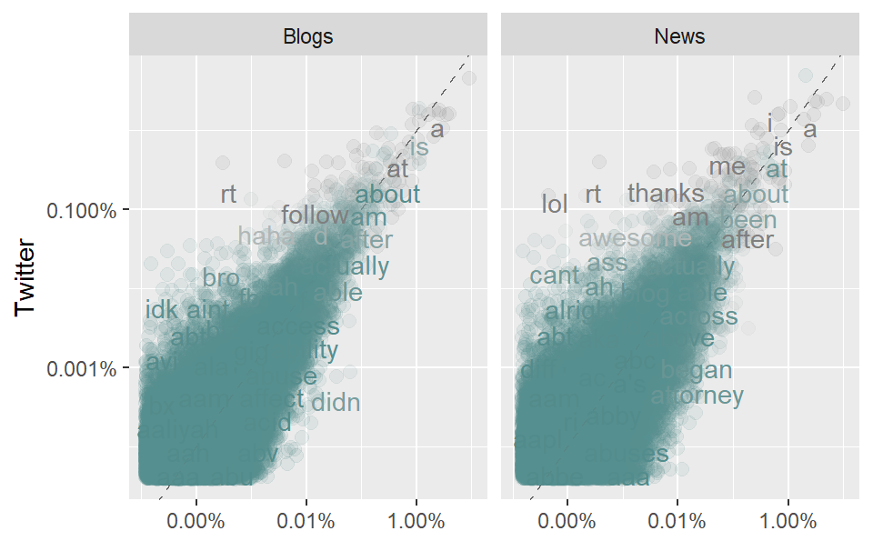

# How to solve the Assignment

1. https://www.tidytextmining.com/ provides an useful approach for how to solve the assignment
   - Frequency Analysis is used
   - (Optional) Sentiment Analysis seems like a good candidate to enhance my approach
2. I will test, if a similar approach is also applicable with the ‘tokenizer’ package as it provided a simple and strong tool for the first visualizations.
3. The prediction system I intent to build up shall differentiate between source
   - The three datasets give three different source
   - (Optional) My shiny application shall differentiate between these source as to give the user to build his own library
   - (Optional) A fourth option will added for all datasets at the same time
   - (Optional) Inputs shall be gathered and used to individualize the predictions to the user.

*I do not know, how applicable each step is. These are all ideas, I would try to implement. If I run short of time, I will focus on the most important part, which is to create a working predictive machine.*